# Standard vs. Natural: Assessing the impact of environmental variables on organic matter decomposition in streams using three substrates

Verena C. Schreiner, Liana Liebmann, Alexander Feckler, Matthias Liess, Moritz Link, Anke Schneeweiss, Amélie Truchy, Wolf von Tümpling, Philipp Vormeier, Oliver Weisner, Ralf B. Schäfer, Mirco Bundschuh

This study was part of the monitoring of small German streams (KgM)

R Script written by Verena C. Schreiner  
checked by Moritz Link

RPTU Kaiserslautern-Landau  
Fortstrasse 7  
76829 Landau  
GERMANY  
Corresponding author mail address: schreiner-verena’@‘uni-landau.de, schreiner.verena’@’rptu.de

# 1 load Tools / Packages

```r
library(plyr)  # version 1.8.7, data manipulation
library(dplyr) # version 1.0.9, data manipulation
library(reshape2) # version 1.4.4, data manipulation
library(moments) # version 0.14.1, check skewness
library(corrplot) # version 0.92, identify correlations
library(PerformanceAnalytics) # version 2.0.4, identify intercorrelation
library(stabs) # version 0.6-4, for stability selection
library(ggplot2) # version 3.3.6, prepare figures
library(cowplot) # version 1.1.1, arrange figures
library(ggeffects) # version 1.1.3, create marginal effects plots


# packages used to calculate the explanatory variables
# library(standartox) # retrieving EC50 values, version: 0.01
# library(OpenStars) # calculating land use in catchments, version: 1.2.3
```

set path

```r
prj <- getwd()
setwd(prj)
```

# 2 Response variables (decompositions)

## 2.1 microbial

### 2.1.1 exposure duration of microbial decomposition substrates

```r
duration <- read.table(file.path(prj, "1_in_out_2019.csv"),
                      header = TRUE,
                      sep = ";",
                      na.strings = c("NR", "NA"))
# remove leaf bag number
duration <- duration[c("siteID", "dateOUT", "dateIN")]
# since always three bags were deployed per sites, these duplicated information on duration are removed
duration <- duration[!duplicated(duration$siteID),]
```

format as dates

```r
duration$dateOUT <- as.Date(duration$dateOUT, "%d.%m.%Y")
duration$dateIN <- as.Date(duration$dateIN, "%d.%m.%Y")
```

duration

```r
duration$duration <- difftime(duration$dateIN, duration$dateOUT, units = c("days"))
```

Read table with explanatory variables to extract mean temperature during exposure

The raw data for environmental variables can be accessed via the PANGEA server mentioned in the manuscript.

```r
exp_var <- read.table(file.path(prj, "5_exp_var_2019.csv"),
                      header = TRUE,
                      sep = ",",
                      na.strings = c("NR", "NA"))

temp <- exp_var[,c("siteID", "temp", "temp_coarse")]
```

### 2.1.2 leaves (microbial)

load data

```r
Leaves <- read.table(file.path(prj, "1_Leaf_weights_2019.csv"),
                      header = TRUE,
                      sep = ";",
                      na.strings = c("NR", "NA"))
```

add temperature + duration

```r
Leaves <- merge(Leaves, temp[,c(1,2)], by="siteID")
Leaves <- merge(Leaves, duration[,c("siteID","duration")], by="siteID")
```

remove those without temperature data + where streams dried out

```r
Leaves_2 <- Leaves[!is.na(Leaves$temp), ]
Leaves_2 <- Leaves_2[!Leaves_2$comment == "dried out", ]
```

add initial leaf weights, each leaf bag was filled with 8 $\pm$ 0.05 g of air dried alder leaves

```r
ini_weight <- read.table(file.path(prj, "1_leaf_weight_start_2019.csv"),
                      header = TRUE,
                      sep = ";",
                      na.strings = c("NR", "NA"))
```

add initial leaf weights to table

```r
leaf_weight <- merge(Leaves_2, ini_weight, by=c("leaf_bag_number"), all.x=TRUE)

nrow(leaf_weight) # 188 single leaf bags
```

```
## [1] 188
```

calculate AFDM End Ash-free dry mass (AFDM) is used to correct for inorganic material attached to the different substrates

```r
leaf_weight$rest_AFDM <- leaf_weight$rest_weight_60 - leaf_weight$rest_weight_500
leaf_weight$OMD_AFDM <- leaf_weight$OMD_weight_60 - leaf_weight$OMD_weight_500
```

In a companion study leaf disks were cut from the leaves and used for studying several endpoints. The AFDM of these leaf disks was also determined and the remaining organic matter is now corrected for these cut leaf disks

```r
# if AFDM information from OMD disks of the same leaf bag is available, use this to calculate ADFM
leaf_weight$afdm_alldisks <- ifelse(!is.na(leaf_weight$OMD_AFDM),
                                       (leaf_weight$OMD_AFDM)/ 7
                                    * leaf_weight$number_disks,
                                                     NA)

# in case no disk information from the respective leaf bag is available, at first use  the mean weight of one disk of the same site and then over all exposed leaf bags, independent of the stream

# calculate mean per stream
mean_afdm_disk <- leaf_weight %>% group_by(siteID) %>%
                  summarise(mean_afdm_disk = mean((afdm_alldisks/number_disks), na.rm = TRUE))

# merge with existing data frame
leaf_weight <- join(leaf_weight, mean_afdm_disk, by =c("siteID"))

# now use this information where AFDM of single bags from a stream are missing
# count samples where information is missing
length(which(is.na(leaf_weight$afdm_alldisks)))
```

```
## [1] 79
```

```r
# 79 samples without information about AFDM of leaf disks now (this includes samples, where no leaf disks were cut)
# use afdm of disks from bags of the same stresm
leaf_weight$afdm_alldisks <- ifelse(!is.na(leaf_weight$afdm_alldisks), leaf_weight$afdm_alldisks,
                                         leaf_weight$mean_afdm_disk * leaf_weight$number_disks)

# check for how many samples afdm information for disks is still missing
length(which(is.na(leaf_weight$afdm_alldisks)))
```

```
## [1] 46
```

```r
# 46 samples
# use afdm of disks from bags irrespective of stream
leaf_weight$afdm_alldisks <- ifelse(!is.na(leaf_weight$afdm_alldisks), leaf_weight$afdm_alldisks,
                                         mean((leaf_weight$OMD_AFDM/7),na.rm = TRUE) * leaf_weight$number_disks)

# total AFDM end
leaf_weight$afdm_end <- leaf_weight$rest_AFDM + (leaf_weight$afdm_alldisks)/1000

# only use those columns you will need for the further analysis
leaf_weight_2 <- leaf_weight[c("siteID", "rep_number", "duration", "temp", "weight_start", "afdm_end")]
```

calculate AFDM of initial leaf weight

normalise the start leaf weight for handling loss and calculate the theoretical initial AFDM

read data

```r
transport <-  read.table(file.path(prj, "1_Transport_leaves_2019.csv"),
                      header = TRUE,
                      sep = ";",
                      na.strings = c("NR", "NA"))
```

calculate percentage differences between start and 60°C (handling loss from initially weight in masses) and 500°C (ashes)

```r
transport$perc_60 <- transport$weight_60 / transport$weight_start
transport$perc_500 <- transport$weight_500 / transport$weight_start
```

now calculate start AFDM based on the transport controls

```r
leaf_weight_2$afdm_start <- ((leaf_weight_2$weight_start) * mean(transport$perc_60)) -
                          ((leaf_weight_2$weight_start) * mean(transport$perc_500))
```

calculate DSM

normalise for exposure duration and mean temperature during exposure using this formula

$$DSM = \left(
\frac{\frac{AFDM_{t0}-AFDM_{t1}}{AFDM_{t0}} *100}{Tn} \right)$$
where $AFDM_{t0}$ is the AFDM before deployment, $AFDM_{t1}$ the AFDM after deployment, $T$ is the mean temperature over the deployment period and $n$ refers to the number of days of deployment

```r
leaf_weight_2$DSM <- (((leaf_weight_2$afdm_start - leaf_weight_2$afdm_end) /
                              leaf_weight_2$afdm_start) * 100)/
                   (leaf_weight_2$temp * as.numeric(leaf_weight_2$duration))

# remove one negative value (weighing error)
leaf_weight_2 <- leaf_weight_2[leaf_weight_2$DSM > 0, ]
```

calculate decomposed mass over whole period (not normalised for temperature and per day)

```r
leaf_weight_2$DSM_absolute <- (((leaf_weight_2$afdm_start - leaf_weight_2$afdm_end) /
                              leaf_weight_2$afdm_start) * 100)
```

only keep important columns

```r
leaf_weight_2 <- leaf_weight_2[,c("siteID", "rep_number", "DSM")]
# data from 187 leaf bags and 64 streams
```

### 2.1.3 cotton strips (microbial)

read in data

```r
Cotton_2019 <- read.table(file.path(prj, "2_Cotton_strips_2019.csv"),
                      header = TRUE,
                      sep = ";",
                      na.strings = c("NR", "NA",""))
```

read in transport cotton used for quality assurance

```r
Cotton_2019_blank <- read.table(file.path(prj, "2_Cotton_strips_2019_transport.csv"),
                      header = TRUE,
                      sep = ";",
                      na.strings = c("NR", "NA",""))
```

add duration + temperature

```r
Cotton_2019 <- merge(Cotton_2019, temp, by="siteID")
Cotton_2019 <- merge(Cotton_2019, duration[,c("siteID","duration")], by="siteID")
```

remove those with comments (since those are broken), without tensile strenght or without temperature information

```r
Cotton_2019 <- Cotton_2019[is.na(Cotton_2019$comment),]
Cotton_2019 <- Cotton_2019[!is.na(Cotton_2019$Peak.tension),]
Cotton_2019 <- Cotton_2019[!is.na(Cotton_2019$temp),]
```

Initially 199 data points, after cleaning 161 data points

To calculate tensile strength loss, normalise tension loss for transport controls, since they were not in the streams –> initial cotton strip tension normalise tension loss for exposure time and average temperature during exposure

Tension loss is calculated like above, instead of AFMD the peak tension is used

```r
Tens_loss <- (((mean(Cotton_2019_blank$Peak.tension) - Cotton_2019$Peak.tension) /
                             mean(Cotton_2019_blank$Peak.tension)) * 100)/
                   (Cotton_2019$temp * as.numeric(Cotton_2019$duration))

# calculate decomposed mass over whole period (not normalised for temperature and per day)
Tens_loss_abs <- (((mean(Cotton_2019_blank$Peak.tension) - Cotton_2019$Peak.tension) /
                             mean(Cotton_2019_blank$Peak.tension)) * 100)

Cotton_2019 <- cbind(Cotton_2019, Tens_loss)
```

```r
# remove five negative values (initial tension was lower then after exposure)
Cotton_2019 <- Cotton_2019[Cotton_2019$Tens_loss > 0, ]
# 156 cotton strips from 63 sites
```

### 2.1.4 decotabs (microbial)

```r
Decotabs_2019 <- read.table(file.path(prj, "3_Decotabs_2019.csv"),
                      header = TRUE,
                      sep = ";", fileEncoding="UTF-8-BOM",
                      na.strings = c("NR", "NA",""))
```

use only fine bags, remove those which were lost / where the stream dried out, save coarse data for later + save an alternative data set

```r
Decotabs_coarse_2019 <- Decotabs_2019[Decotabs_2019$type == "coarse",]
Decotabs_2019 <- Decotabs_2019[Decotabs_2019$type == "fine",]

Decotabs_2019 <- Decotabs_2019[is.na(Decotabs_2019$comment) | ! Decotabs_2019$comment == "lost" & ! Decotabs_2019$comment == "dried out" , ]
```

remove empty bags

```r
Decotabs_2019 <- Decotabs_2019[is.na(Decotabs_2019$comment) | !Decotabs_2019$comment == "empty", ]
```

10 bags removed

calculate afdm

```r
Decotabs_2019$afdm_end <- Decotabs_2019$weight_60 - Decotabs_2019$weight_500
```

```r
Decotabs_transport_2019 <- read.table(file.path(prj, "3_Decotabs_2019_transport_controls.csv"),
                      header = TRUE,
                      sep = ";", fileEncoding="UTF-8-BOM",
                      na.strings = c("NR", "NA",""))
```

calculate afdm of Decotabs transport controls, use only fine bags to estimate the initial afdm; create subset file for coarse decotab bags

```r
Decotabs_coarse_transport_2019 <- Decotabs_transport_2019[Decotabs_transport_2019$type == "coarse", ]
Decotabs_transport_2019 <- Decotabs_transport_2019[Decotabs_transport_2019$type == "fine", ]

Decotabs_transport_2019$afdm_end <- Decotabs_transport_2019$weight_60 - Decotabs_transport_2019$weight_500
mean_Decot_trans <- mean(Decotabs_transport_2019$afdm_end)
```

add duration + temperature

```r
Decotabs_2019 <- merge(Decotabs_2019, temp, by="siteID")

Decotabs_2019 <- merge(Decotabs_2019, duration[,c(1,4)], by="siteID")
```

calculate decomposition and normalise for exposure duration and average temperature during exposure

```r
Decotabs_2019$DSM <- (((mean_Decot_trans - Decotabs_2019$afdm_end) /
                              mean_Decot_trans) * 100)/
                   (Decotabs_2019$temp * as.numeric(Decotabs_2019$duration))
```

calculate abolute decomposed substrate mass

```r
Decotabs_2019$DSM_abs <- (((mean_Decot_trans - Decotabs_2019$afdm_end) /
                              mean_Decot_trans) * 100)
```

remove NAs + negative values (transport control lower afdm than those exposed in the stream)

```r
Decotabs_2019 <- Decotabs_2019[! is.na(Decotabs_2019$DSM) & Decotabs_2019$DSM > 0, ]
# 185 observations from 63 streams
```

### 2.1.5 combine all decomposition substrates in one dataframe

```r
# read in replicate number
Replicates_2019 <- read.table(file.path(prj, "4_Replicates_2019.csv"),
                      header = TRUE,
                      sep = ";",
                      na.strings = c("NR", "NA",""))

Decom_2019 <- Replicates_2019
Decom_2019 <- merge(Decom_2019, leaf_weight_2, by=c("siteID", "rep_number"), all.x = TRUE)
names(Decom_2019)[3] <- c("DSM_leaves")
Decom_2019 <- merge(Decom_2019, Cotton_2019[,c(1,2,8)], by=c("siteID", "rep_number"), all.x = TRUE)
Decom_2019 <- merge(Decom_2019, Decotabs_2019[,c(1,3,12)], by=c("siteID", "rep_number"), all.x = TRUE)
names(Decom_2019)[5] <- c("DSM_Decotabs")

# remove rows (streams / replicated) with only NAs (no values for all substrates)
# counter intuitive to use | instead of &, but only when using | rows are removed where all three values are NA.
# With & all rows are removed where at least one NA occurs
Decom_2019 <- Decom_2019[!is.na(Decom_2019$DSM_leaves) | !is.na(Decom_2019$Tens_loss) |
                           !is.na(Decom_2019$DSM_Decotabs), ]
# data from 63 streams
```

## 2.2 total

### 2.2.1 leaves (total)

read in data

```r
Macroinv_leaves <- read.table(file.path(prj, "1_Leaves_coarse.csv"), # change file
                      header = TRUE,
                      sep = ";",
                      na.strings = c("NR", "NA"))
```

calculate exposure duration of total leaf decomposition format as dates

```r
Macroinv_leaves$dateOUT <- as.Date(Macroinv_leaves$dateOUT, "%d.%m.%Y")
Macroinv_leaves$dateIN <- as.Date(Macroinv_leaves$dateIN, "%d.%m.%Y")
```

duration

```r
Macroinv_leaves$duration_coarse <- difftime(Macroinv_leaves$dateIN, Macroinv_leaves$dateOUT, units = c("days"))
```

add mean temperature to file

```r
Macroinv_leaves <- merge(Macroinv_leaves, temp[,c(1,3)])
```

remove entries without temperature data

```r
Macroinv_leaves <- Macroinv_leaves[!is.na(Macroinv_leaves$temp_coarse), ]
```

limit to coarse bags

```r
Macroinv_leaves <- Macroinv_leaves[Macroinv_leaves$type == "coarse",]
```

remove entries without reliable data (problems in leaf bag numbers, lost during drying etc.)

```r
Macroinv_leaves <- Macroinv_leaves[Macroinv_leaves$comments == "", ]
# remove 19 entries
```

calculate AFDM End

```r
Macroinv_leaves$afdm_end <- Macroinv_leaves$rest_weight_60 - Macroinv_leaves$rest_weight_500
```

calculate AFDM of initial leaf weight

normalise the initial leaf weight for handling loss and calculate the theoretical initial AFDM

read data

```r
transport_macro <-  read.table(file.path(prj, "1_Transport_leaves_coarse_2019.csv"),
                      header = TRUE,
                      sep = ";",
                      na.strings = c("NR", "NA"))

# only keep coarse bags
transport_macro <- transport_macro[!transport_macro$type == "fine", ]
```

calculate percentage differences between start and 60 degree (handling loss from initially weight in masses) and 500°C (ashes)

```r
transport_macro$perc_60 <- transport_macro$weight_60 / transport_macro$initial.weight
transport_macro$perc_500 <- transport_macro$weight_500 / transport_macro$initial.weight
```

now calculate start AFDM based on the transport controls

```r
Macroinv_leaves$afdm_start <- ((Macroinv_leaves$weight_start) * mean(transport_macro$perc_60)) -
                              ((Macroinv_leaves$weight_start) * mean(transport_macro$perc_500))
```

calculate DSM

normalise for exposure duration and mean temperature during exposure (per degree day)

```r
Macroinv_leaves$DSM <- (((Macroinv_leaves$afdm_start - Macroinv_leaves$afdm_end) /
                              Macroinv_leaves$afdm_start) * 100)/
                   (Macroinv_leaves$temp_coarse * as.numeric(Macroinv_leaves$duration_coarse))

# check for negative values (weighing errors)
nrow(Macroinv_leaves[Macroinv_leaves$DSM < 0, ]) # all values positive
```

```
## [1] 0
```

calculate absolute decomposed substrate mass

```r
Macroinv_leaves$DSM_abs <- (((Macroinv_leaves$afdm_start - Macroinv_leaves$afdm_end) /
                              Macroinv_leaves$afdm_start) * 100)
```

only keep important columns

```r
Macroinv_leaves <- Macroinv_leaves[,c("siteID", "rep_number", "DSM")]
# data from 179 leaf bags and 66 streams
```

### 2.2.2 decotabs (total)

use only coarse bags, remove those which were lost / where the stream dried out

```r
Decotabs_coarse_2019 <- Decotabs_coarse_2019[is.na(Decotabs_coarse_2019$comment) | ! Decotabs_coarse_2019$comment == "lost" &
                                               ! Decotabs_coarse_2019$comment == "dried out" &
                                                 ! Decotabs_coarse_2019$comment == "sampling site not assignable" , ]
```

remove empty bags

```r
Decotabs_coarse_2019 <- Decotabs_coarse_2019[is.na(Decotabs_coarse_2019$comment) | !Decotabs_coarse_2019$comment == "empty", ]
```

a lot of bags removed, only 88 remaining

calculate afdm

```r
Decotabs_coarse_2019$afdm_end <- Decotabs_coarse_2019$weight_60 - Decotabs_coarse_2019$weight_500
```

calculate afdm of Decotabs transport controls, use only coarse to estimate the initial afdm

```r
Decotabs_coarse_transport_2019$afdm_end <- Decotabs_coarse_transport_2019$weight_60 - Decotabs_coarse_transport_2019$weight_500
mean_Decot_coarse_trans <- mean(Decotabs_coarse_transport_2019$afdm_end)
```

add duration + temperature

```r
Decotabs_coarse_2019 <- merge(Decotabs_coarse_2019, temp, by="siteID")

Decotabs_coarse_2019 <- merge(Decotabs_coarse_2019, duration[,c(1,4)], by="siteID")
```

calculate decomposition normalise for exposure duration and average temperature during exposure

```r
Decotabs_coarse_2019$DSM <- (((mean_Decot_coarse_trans - Decotabs_coarse_2019$afdm_end) /
                              mean_Decot_coarse_trans) * 100)/
                   (Decotabs_coarse_2019$temp * as.numeric(Decotabs_coarse_2019$duration))
```

do not use temp_coarse, since this is from the other time point of the coarse leaf bags

remove negative values (transport control lower afdm than those exposed in the stream)

```r
Decotabs_coarse_2019 <- Decotabs_coarse_2019[! is.na(Decotabs_coarse_2019$DSM) & !Decotabs_coarse_2019$DSM < 0, ]
# 81 observations from 34 streams
```

calculate absolute decomposed substrate mass

```r
Decotabs_coarse_2019$DSM_abs <- (((mean_Decot_coarse_trans - Decotabs_coarse_2019$afdm_end) /
                              mean_Decot_coarse_trans) * 100)
```

change name of replicate number column

```r
names(Decotabs_coarse_2019)[3] <- "rep_number"
```

### 2.2.3 add total decomposition substrate to the dataframe

```r
Decom_2019_all <- merge(Decom_2019, Macroinv_leaves, by=c("siteID", "rep_number"), all.x = TRUE)
names(Decom_2019_all)[6] <- c("DSM_leaves_coarse")
Decom_2019_all <- merge(Decom_2019_all, Decotabs_coarse_2019[,c(1,3,12)], by=c("siteID", "rep_number"), all.x = TRUE)
names(Decom_2019_all)[7] <- c("DSM_Decotabs_coarse")
```

# 3 compare microbial decomposition of different substrates

at first check for skewness

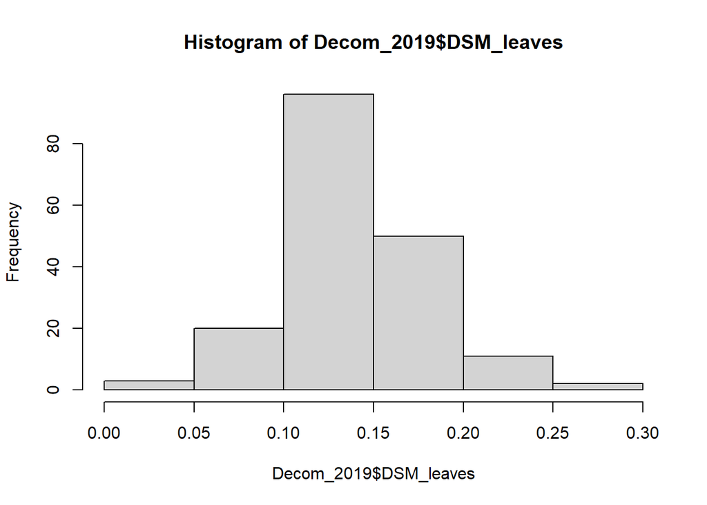

```r
hist(Decom_2019$DSM_leaves)  # data not skewed
```

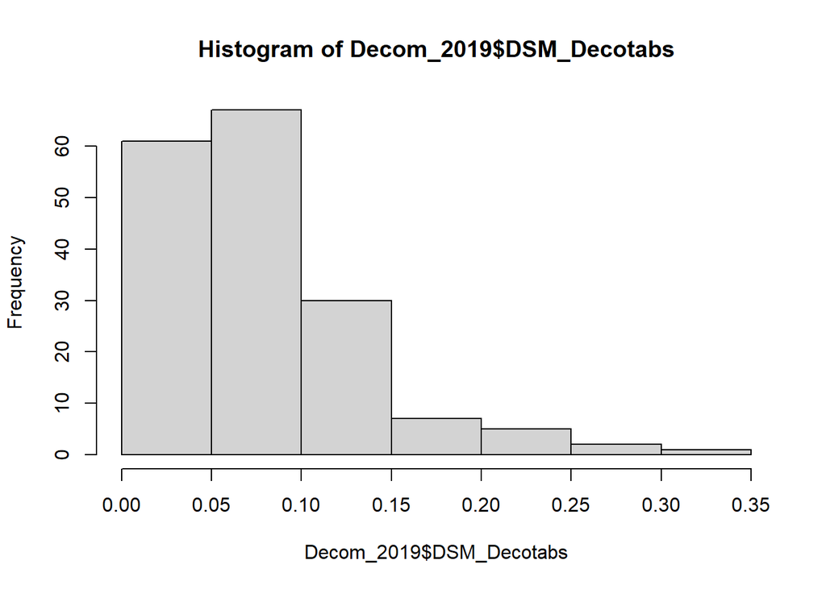

```r
hist(Decom_2019$DSM_Decotabs) # right skewed, wide range of data
```

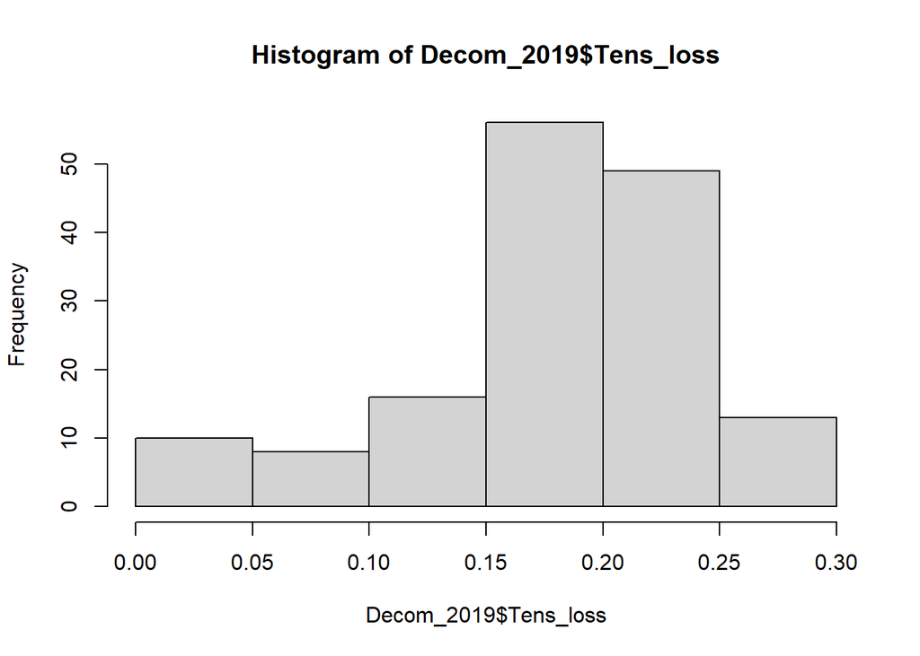

```r
hist(Decom_2019$Tens_loss)    # slightly left skewed
```

the decotabs data as well as those from the cotton strips are skewed, consider transformation

```r
# Decotabs
skewness(Decom_2019$DSM_Decotabs, na.rm = TRUE) # positively skewed, below |2|, but since over more than one magnitude transform at least for direct comparison
```

```
## [1] 1.686297
```

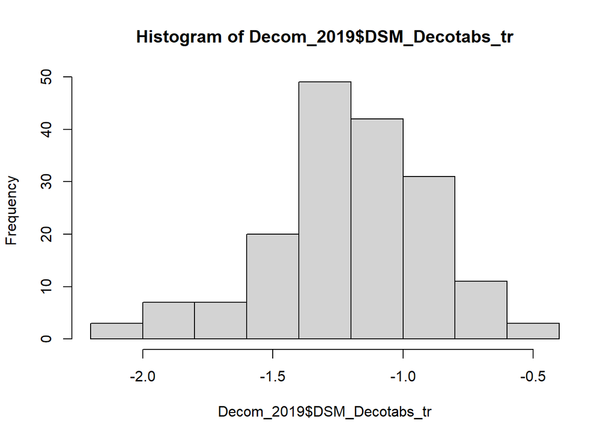

```r
Decom_2019$DSM_Decotabs_tr <- log10(Decom_2019$DSM_Decotabs)
hist(Decom_2019$DSM_Decotabs_tr) # after transformation skew almost gone, use transformed data in direct comparision
```

```r
skewness(Decom_2019$DSM_Decotabs_tr, na.rm = TRUE)
```

```
## [1] -0.5389064
```

```r
#
# Cotton strips
skewness(Decom_2019$Tens_loss, na.rm = TRUE) # negatively skewed, but below |1| not transformed
```

```
## [1] -0.9005459
```

## 3.1 leaves vs. decotabs

plot non-transformed data

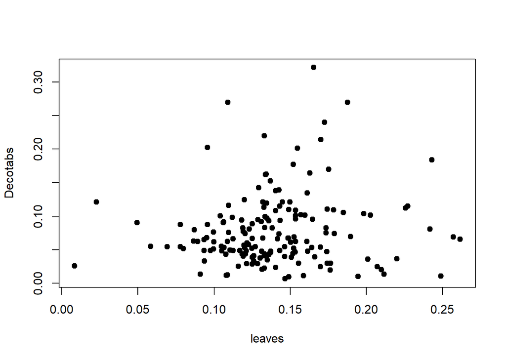

```r
plot(Decom_2019$DSM_leaves, Decom_2019$DSM_Decotabs, pch = 19, ylab = "Decotabs", xlab = "leaves")
```

```r
cor.test(Decom_2019$DSM_leaves, Decom_2019$DSM_Decotabs)$p.value
```

```
## [1] 0.2062436
```

```r
round(as.numeric(cor.test(Decom_2019$DSM_leaves, Decom_2019$DSM_Decotabs)$estimate)^2,3) # r2 = 0.01
```

```
## [1] 0.01
```

plot transformed data

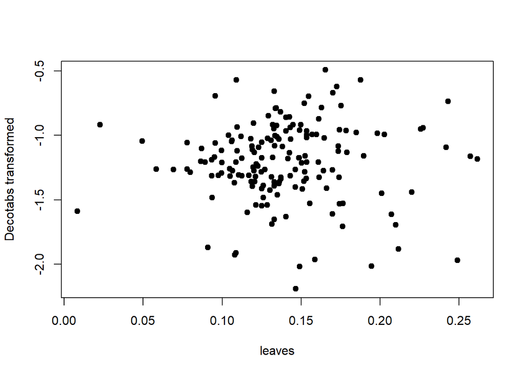

```r
plot(Decom_2019$DSM_leaves, Decom_2019$DSM_Decotabs_tr, pch = 19, ylab = "Decotabs transformed", xlab = "leaves")
```

```r
cor.test(Decom_2019$DSM_leaves, Decom_2019$DSM_Decotabs_tr)$p.value
```

```
## [1] 0.898423
```

```r
round(as.numeric(cor.test(Decom_2019$DSM_leaves, Decom_2019$DSM_Decotabs_tr)$estimate)^2,3) # r2 < 0.01
```

```
## [1] 0
```

no relationship

## 3.2 leaves vs cotton strips

plot non-transformed

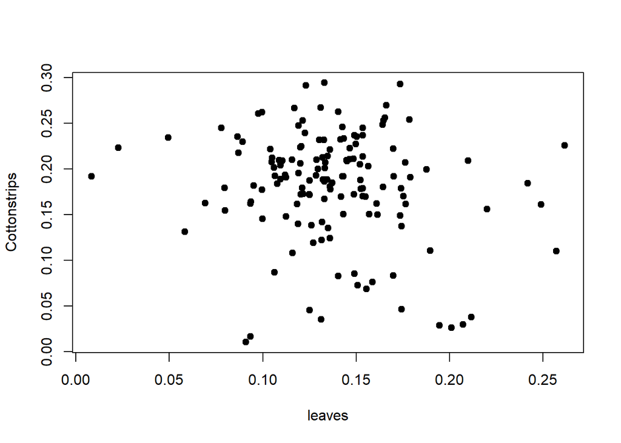

```r
plot(Decom_2019$DSM_leaves, Decom_2019$Tens_loss, pch = 19, ylab = "Cottonstrips", xlab = "leaves")
```

```r
cor.test(Decom_2019$DSM_leaves, Decom_2019$Tens_loss)$p.value
```

```
## [1] 0.05275945
```

```r
round(as.numeric(cor.test(Decom_2019$DSM_leaves, Decom_2019$Tens_loss)$estimate)^2,3) # r2 = 0.026
```

```
## [1] 0.026
```

very weak relationship

## 3.3 cotton vs decotabs

plot non-transformed data

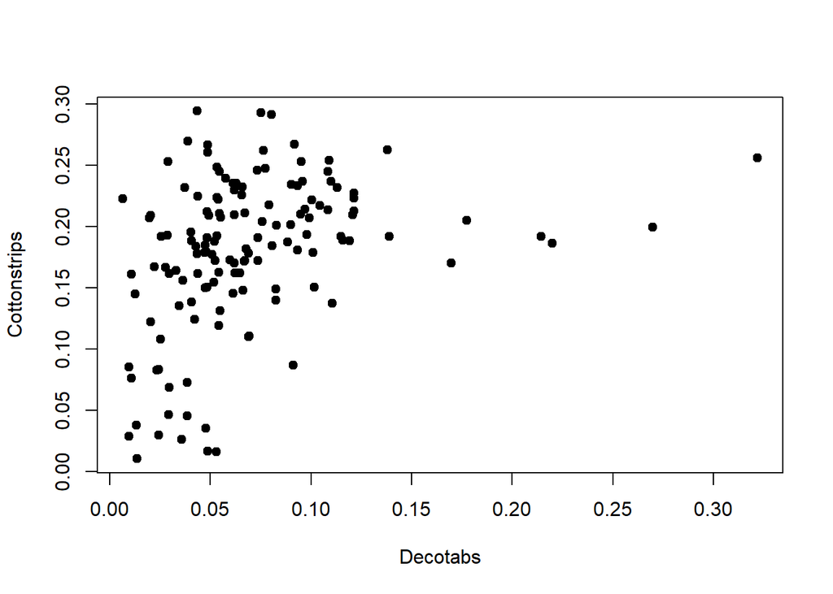

```r
plot(Decom_2019$DSM_Decotabs, Decom_2019$Tens_loss, pch = 19, xlab = "Decotabs", ylab = "Cottonstrips")
```

```r
cor.test(Decom_2019$DSM_Decotabs, Decom_2019$Tens_loss)$p.value
```

```
## [1] 1.900599e-05
```

```r
round(as.numeric(cor.test(Decom_2019$DSM_Decotabs, Decom_2019$Tens_loss)$estimate)^2,3) # r2 = 0.126
```

```
## [1] 0.126
```

weak relationship

only deco transformed

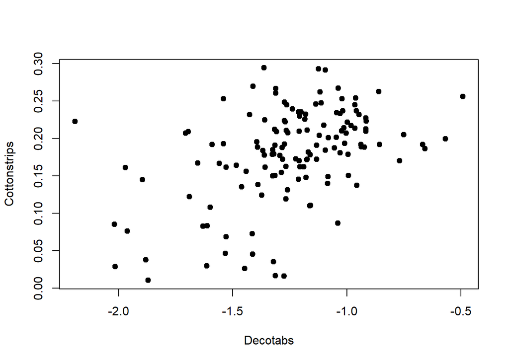

```r
plot(Decom_2019$DSM_Decotabs_tr, Decom_2019$Tens_loss, pch = 19, xlab = "Decotabs", ylab = "Cottonstrips")
```

```r
cor.test(Decom_2019$DSM_Decotabs_tr, Decom_2019$Tens_loss)$p.value
```

```
## [1] 2.343492e-08
```

```r
round(as.numeric(cor.test(Decom_2019$DSM_Decotabs_tr, Decom_2019$Tens_loss)$estimate)^2,3) # r2 = 0.206
```

```
## [1] 0.206
```

moderate relationship

## 3.4 create Figure 1 providing relationships

```r
# Leaves vs. Decotabs
# decotabs transformed
p1 <- ggplot(data = Decom_2019, aes(x = DSM_leaves, y = DSM_Decotabs))+
  scale_y_log10() +
  geom_point(size = 2) +
  ggtitle("") +
  ylab("Decomposed decotabs mass [%] per dday")+
  xlab("Decomposed leaf mass [%] per dday") +
  labs(subtitle = "A") +
  annotate("text", x = 0.04, y=0.012, label = paste("~italic(r)^2 <", 0.01), parse=TRUE, size = 3.5)+
  annotate("text", x = 0.04, y=0.008, label = "italic(p) == 0.898", parse=TRUE,  size = 3.5)+
  theme_classic()+
  theme(axis.text.x = element_text(colour="black", size = 12),
        axis.text.y = element_text(colour="black", size = 12),
        plot.subtitle = element_text(colour="black", size = 14),
        legend.position="none", strip.text.x = element_text(face = "bold"),
        text = element_text(size=11), plot.title = element_text(hjust = 0.5))


# Leaves + cotton strips
p2 <- ggplot(data = Decom_2019, aes(x = DSM_leaves, y = Tens_loss))+
  geom_point(size = 2) +
  ggtitle("") +
  ylab("Tension loss  [%] per dday")+
  xlab("Decomposed leaf mass [%] per dday") +
  labs(subtitle = "B") +
  annotate("text", x = 0.04, y=0.05, label = paste("~italic(r)^2 ==", 0.03), parse=TRUE, size = 3.5)+
    annotate("text", x = 0.04, y=0.02, label = "italic(p) == 0.053", parse=TRUE, size = 3.5)+
  theme_classic()+
  theme(axis.text.x = element_text(colour="black", size = 12),
        axis.text.y = element_text(colour="black", size = 12),
        plot.subtitle = element_text(colour="black", size = 14),
        legend.position="none", strip.text.x = element_text(face = "bold"),
        text = element_text(size=11), plot.title = element_text(hjust = 0.5))


# Decotabs vs. cotton strips
# decotabs transformed
p3 <- ggplot(data = Decom_2019, aes(x = DSM_Decotabs, y = Tens_loss))+
  scale_x_log10() +
  geom_point(size = 2) +
  ggtitle("") +
  ylab("Tension loss  [%] per dday")+
  xlab("Decomposed decotabs mass [%] per dday") +
  labs(subtitle = "C") +
  annotate("text", x = 0.25, y=0.05, label = paste("~italic(r)^2 ==", 0.21), parse=TRUE, size = 3.5)+
  annotate("text", x = 0.25, y=0.02, label = "italic(p) < 0.001", parse=TRUE, size = 3.5)+
  theme_classic()+
  theme(axis.text.x = element_text(colour="black", size = 12),
        axis.text.y = element_text(colour="black", size = 12),
        plot.subtitle = element_text(colour="black", size = 14),
        legend.position="none", strip.text.x = element_text(face = "bold"),
        text = element_text(size=11), plot.title = element_text(hjust = 0.5))


png(filename="Figure_1_substrate_comparison.png", width=7, height=7, units="in", res = 900)
# create a matrix to center the lower figure in the middle
ggdraw() +
  draw_plot(p1, x = 0, y = 0.5, width = 0.5, height = 0.5) +
  draw_plot(p2, x = 0.5, y = 0.5, width = 0.5, height = 0.5) +
  draw_plot(p3, x = 0.25, y = 0, width = 0.5, height = 0.5)

dev.off()
```

create Figure S2 - Version with original (not transformed) data

```r
p1_n_t <- ggplot(data = Decom_2019, aes(x = DSM_leaves, y = DSM_Decotabs))+
  geom_point(size = 2) +
  ggtitle("") +
  ylab("Decomposed decotabs mass [%] per dday")+
  xlab("Decomposed leaf mass [%] per dday") +
  labs(subtitle = "A") +
  annotate("text", x = 0.04, y=0.31, label = paste("~italic(r)^2 ==", 0.01), parse=TRUE, size = 3.5)+
    annotate("text", x = 0.04, y=0.29, label = "italic(p) == 0.206", parse=TRUE, size = 3.5)+
  theme_classic()+
  theme(axis.text.x = element_text(colour="black", size = 12),
        axis.text.y = element_text(colour="black", size = 12),
        plot.subtitle = element_text(colour="black", size = 14),
        legend.position="none", strip.text.x = element_text(face = "bold"),
        text = element_text(size=11), plot.title = element_text(hjust = 0.5))



# Decotabs vs. cotton strips
# decotabs transformed
p3_n_t <- ggplot(data = Decom_2019, aes(x = DSM_Decotabs, y = Tens_loss))+
  geom_point(size = 2) +
  ggtitle("") +
  ylab("Tension loss  [%] per dday")+
  xlab("Decomposed decotabs mass [%] per dday") +
  labs(subtitle = "C") +
  annotate("text", x = 0.25, y=0.05, label = paste("~italic(r)^2 ==", 0.13), parse=TRUE, size = 3.5)+
  annotate("text", x = 0.25, y=0.02, label = "italic(p) < 0.001", parse=TRUE, size = 3.5)+
  theme_classic()+
  theme(axis.text.x = element_text(colour="black", size = 12),
        axis.text.y = element_text(colour="black", size = 12),
        plot.subtitle = element_text(colour="black", size = 14),
        legend.position="none", strip.text.x = element_text(face = "bold"),
        text = element_text(size=11), plot.title = element_text(hjust = 0.5))


png(filename="Figure_S2_method_comparison_non_transformed.png", width=7, height=7, units="in", res = 900)
# create a matrix to center the lower figure in the middle
ggdraw() +
  draw_plot(p1_n_t, x = 0, y = 0.5, width = 0.5, height = 0.5) +
  draw_plot(p2, x = 0.5, y = 0.5, width = 0.5, height = 0.5) +
  draw_plot(p3_n_t, x = 0.25, y = 0, width = 0.5, height = 0.5)

dev.off()
```

## 3.5 calculate interreplicate variability

microbial leaves

```r
# absolute
mean(with(Decom_2019, tapply(DSM_leaves, siteID, var)), na.rm = TRUE) # 0.000682934
```

```
## [1] 0.000682934
```

```r
# relative [%]
mean(with(Decom_2019, tapply(DSM_leaves, siteID, var))/ with(Decom_2019, tapply(DSM_leaves, siteID, mean)), na.rm = TRUE)*100 # 0.46 %
```

```
## [1] 0.4574444
```

cotton strips

```r
# absolute
mean(with(Decom_2019, tapply(Tens_loss, siteID, var)), na.rm = TRUE) # 0.001353008
```

```
## [1] 0.001353008
```

```r
# relative [%]
mean(with(Decom_2019, tapply(Tens_loss, siteID, var))/ with(Decom_2019, tapply(Tens_loss, siteID, mean)), na.rm = TRUE)*100 # 0.92 %
```

```
## [1] 0.9219029
```

microbial decotabs

```r
# absolute
mean(with(Decom_2019, tapply(DSM_Decotabs, siteID, var)), na.rm = TRUE) # 0.001533229
```

```
## [1] 0.001533229
```

```r
# relative [%]
mean(with(Decom_2019, tapply(DSM_Decotabs, siteID, var))/ with(Decom_2019, tapply(DSM_Decotabs, siteID, mean)), na.rm = TRUE)*100 # 1.51 %
```

```
## [1] 1.511785
```